# Tongue FACS Notebook

Enter the directory of the maca folder on your drive and the name of the tissue you want to analyze.

```r
tissue_of_interest = "Tongue"
```

Load the requisite packages and some additional helper functions.

```r
library(here)
library(useful)
library(Seurat)
library(dplyr)
library(Matrix)

save_dir = here('00_data_ingest', 'tissue_robj')
```

```r
# read the metadata to get the plates we want
plate_metadata_filename = here('00_data_ingest', 'facs_raw_data', 'metadata_FACS.csv')

plate_metadata <- read.csv(plate_metadata_filename, sep=",", header = TRUE)
colnames(plate_metadata)[1] <- "plate.barcode"
plate_metadata
```

| plate.barcode | mouse.id | tissue | subtissue | FACS.selection | mouse.sex |
| --- | --- | --- | --- | --- | --- |
| D041914 | 3_8_M | Bladder | NA | Multiple | M |
| D042253 | 3_9_M | Bladder | NA | Multiple | M |
| MAA000487 | 3_10_M | Bladder | NA | Multiple | M |
| B000610 | 3_56_F | Bladder | NA | Multiple | F |
| B002764 | 3_38_F | Bladder | NA | Multiple | F |
| B002771 | 3_39_F | Bladder | NA | Multiple | F |
| MAA000538 | 3_8_M | Brain_Neurons | Cerebellum | Neurons | M |
| MAA000550 | 3_10_M | Brain_Neurons | Hippocampus | Neurons | M |
| MAA000553 | 3_10_M | Brain_Neurons | Hippocampus | NA | M |
| MAA000560 | 3_10_M | Brain_Neurons | Cortex | Neurons | M |

[output cut: 237 more lines]

Subset the metadata on the tissue.

```r
tissue_plates = filter(plate_metadata, tissue == tissue_of_interest)[,c('plate.barcode','tissue','subtissue','mouse.sex')]
tissue_plates
```

| plate.barcode | tissue | subtissue | mouse.sex |
| --- | --- | --- | --- |
| D041894 | Tongue | NA | M |
| D041904 | Tongue | NA | M |
| D041911 | Tongue | NA | M |
| B002777 | Tongue | NA | F |
| B002780 | Tongue | NA | F |

Load the read count data.

```r
#Load the gene names and set the metadata columns by opening the first file
filename = here('00_data_ingest', 'facs_raw_data', 'FACS', paste0(tissue_of_interest, '-counts.csv'))

raw.data = read.csv(filename, sep=",", row.names=1)
# raw.data = data.frame(row.names = rownames(raw.data))
corner(raw.data)
```

| A15.D041894.3_9_M.1.1 | B19.D041894.3_9_M.1.1 | C21.D041894.3_9_M.1.1 | E1.D041894.3_9_M.1.1 | F4.D041894.3_9_M.1.1 |
| --- | --- | --- | --- | --- |
| 0 | 0 | 0 | 0 | 0 |
| 130 | 130 | 44 | 23 | 101 |
| 0 | 0 | 0 | 0 | 0 |
| 0 | 0 | 0 | 0 | 0 |
| 2 | 88 | 6 | 18 | 0 |

Make a vector of plate barcodes for each cell

```r
plate.barcodes = lapply(colnames(raw.data), function(x) strsplit(strsplit(x, "_")[[1]][1], '.', fixed=TRUE)[[1]][2])
head(plate.barcodes)
```

```
[[1]]
[1] "D041894"

[[2]]
[1] "D041894"

[[3]]
[1] "D041894"

[[4]]
[1] "D041894"

[[5]]
[1] "D041894"

[[6]]
[1] "D041894"
```

```
D041894
```

```
D041894
```

```
D041894
```

```
D041894
```

```
D041894
```

```
D041894
```

```r
barcode.df = t.data.frame(as.data.frame(plate.barcodes))

rownames(barcode.df) = colnames(raw.data)
colnames(barcode.df) = c('plate.barcode')
head(barcode.df)
```

```
                      plate.barcode
A15.D041894.3_9_M.1.1 "D041894"
B19.D041894.3_9_M.1.1 "D041894"
C21.D041894.3_9_M.1.1 "D041894"
E1.D041894.3_9_M.1.1  "D041894"
F4.D041894.3_9_M.1.1  "D041894"
G7.D041894.3_9_M.1.1  "D041894"
```

```
D041894

D041894

D041894

D041894

D041894

D041894
```

```r
rnames = row.names(barcode.df)
meta.data <- merge(barcode.df, plate_metadata, by='plate.barcode', sort = F)
row.names(meta.data) <- rnames

# Sort cells by plate barcode because that's how the data was originally
meta.data = meta.data[order(meta.data$plate.barcode), ]
corner(meta.data)
```

| plate.barcode | mouse.id | tissue | subtissue | FACS.selection |
| --- | --- | --- | --- | --- |
| B002777 | 3_39_F | Tongue | NA | Multiple |
| B002777 | 3_39_F | Tongue | NA | Multiple |
| B002777 | 3_39_F | Tongue | NA | Multiple |
| B002777 | 3_39_F | Tongue | NA | Multiple |
| B002777 | 3_39_F | Tongue | NA | Multiple |

```r
raw.data = raw.data[, rownames(meta.data)]
corner(raw.data)
```

| A13.B002777.3_39_F.1.1 | B18.B002777.3_39_F.1.1 | D6.B002777.3_39_F.1.1 | E20.B002777.3_39_F.1.1 | G8.B002777.3_39_F.1.1 |
| --- | --- | --- | --- | --- |
| 0 | 0 | 0 | 0 | 0 |
| 728 | 148 | 193 | 72 | 66 |
| 1 | 222 | 0 | 156 | 0 |
| 0 | 0 | 0 | 0 | 0 |
| 0 | 0 | 0 | 0 | 0 |

Process the raw data and load it into the Seurat object.

```r
# Find ERCC's, compute the percent ERCC, and drop them from the raw data.
erccs <- grep(pattern = "^ERCC-", x = rownames(x = raw.data), value = TRUE)
percent.ercc <- Matrix::colSums(raw.data[erccs, ])/Matrix::colSums(raw.data)
ercc.index <- grep(pattern = "^ERCC-", x = rownames(x = raw.data), value = FALSE)
raw.data <- raw.data[-ercc.index,]

# Create the Seurat object with all the data
tiss <- CreateSeuratObject(raw.data = raw.data, project = tissue_of_interest,
                    min.cells = 5, min.genes = 5)

tiss <- AddMetaData(object = tiss, meta.data)
tiss <- AddMetaData(object = tiss, percent.ercc, col.name = "percent.ercc")
# Change default name for sums of counts from nUMI to nReads
colnames(tiss@meta.data)[colnames(tiss@meta.data) == 'nUMI'] <- 'nReads'

# Create metadata columns for annotations and subannotations
tiss@meta.data[,'annotation'] <- NA
tiss@meta.data[,'subannotation'] <- NA
```

Calculate percent ribosomal genes.

```r
ribo.genes <- grep(pattern = "^Rp[sl][[:digit:]]", x = rownames(x = tiss@data), value = TRUE)
percent.ribo <- Matrix::colSums(tiss@raw.data[ribo.genes, ])/Matrix::colSums(tiss@raw.data)
tiss <- AddMetaData(object = tiss, metadata = percent.ribo, col.name = "percent.ribo")
```

A sanity check: genes per cell vs reads per cell.

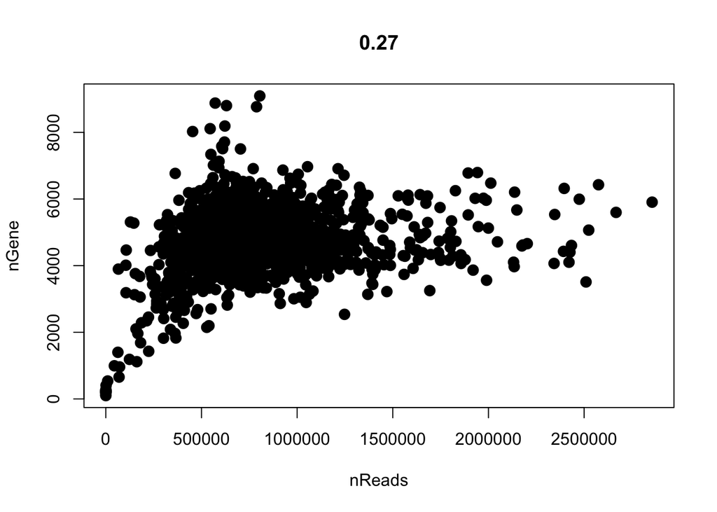

```r
GenePlot(object = tiss, gene1 = "nReads", gene2 = "nGene", use.raw=T)
```

Filter out cells with few reads and few genes.

```r
tiss <- FilterCells(object = tiss, subset.names = c("nGene", "nReads"),
    low.thresholds = c(500, 50000), high.thresholds = c(25000, 2000000))
```

Normalize the data, then regress out correlation with total reads

```r
tiss <- NormalizeData(object = tiss)
tiss <- ScaleData(object = tiss, vars.to.regress = c("nReads", "percent.ribo","Rn45s"))
```

```
[1] "Regressing out nReads"       "Regressing out percent.ribo"
[3] "Regressing out Rn45s"

[1] "Scaling data matrix"
```

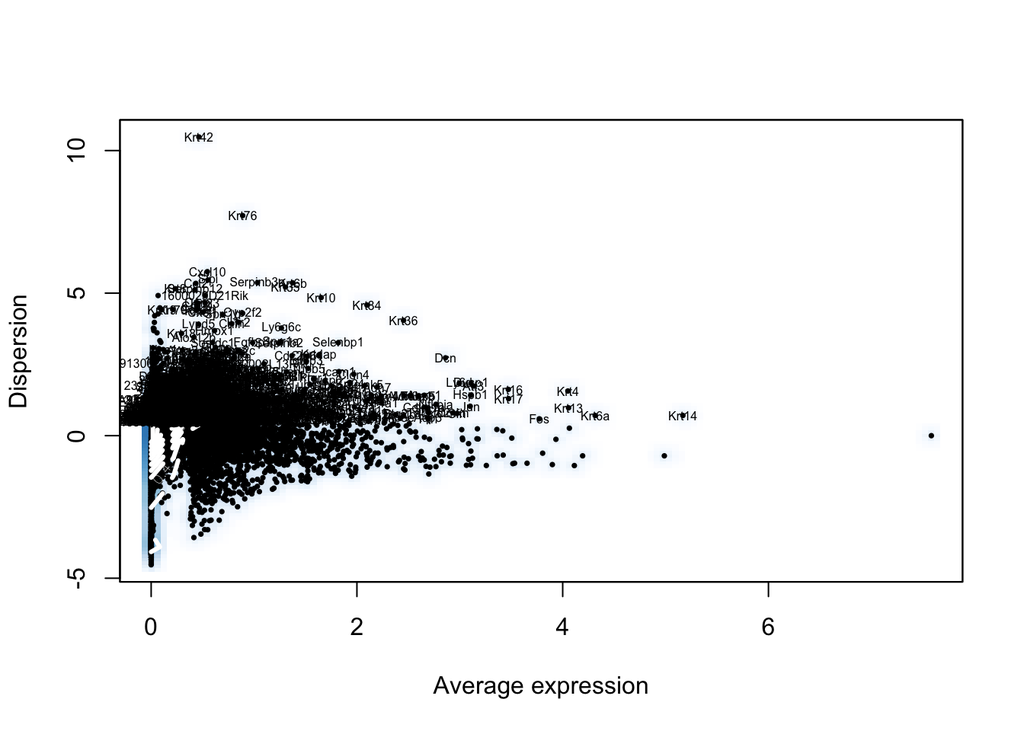

```r
tiss <- FindVariableGenes(object = tiss, do.plot = TRUE, x.high.cutoff = Inf, y.cutoff = 0.5)
```

Run Principal Component Analysis.

```r
tiss <- RunPCA(object = tiss, do.print = FALSE)
tiss <- ProjectPCA(object = tiss, do.print = FALSE)
```

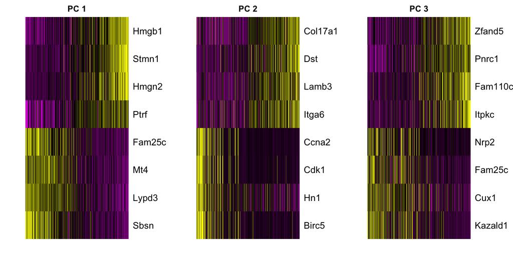

Later on (in FindClusters and TSNE) you will pick a number of principal components to use. This has the effect of keeping the major directions of variation in the data and, ideally, supressing noise. There is no correct answer to the number to use, but a decent rule of thumb is to go until the plot plateaus.

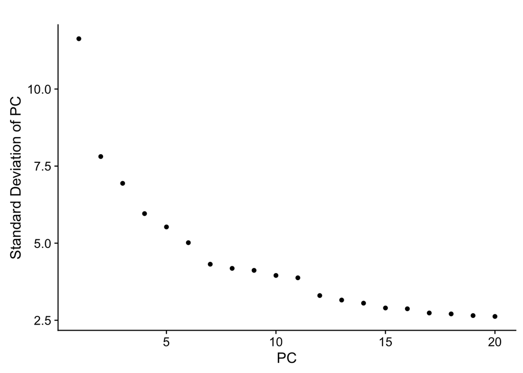

```r
PCElbowPlot(object = tiss)
```

Choose the number of principal components to use.

```r
# Set number of principal components.
n.pcs = 15
```

The clustering is performed based on a nearest neighbors graph. Cells that have similar expression will be joined together. The Louvain algorithm looks for groups of cells with high modularity–more connections within the group than between groups. The resolution parameter determines the scale…higher resolution will give more clusters, lower resolution will give fewer.

For the top-level clustering, aim to under-cluster instead of over-cluster. It will be easy to subset groups and further analyze them below.

```r
# Set resolution
res.used <- 0.9

tiss <- FindClusters(object = tiss, reduction.type = "pca", dims.use = 1:n.pcs,
    resolution = res.used, print.output = 0, save.SNN = TRUE, force.recalc = TRUE)
```

To visualize

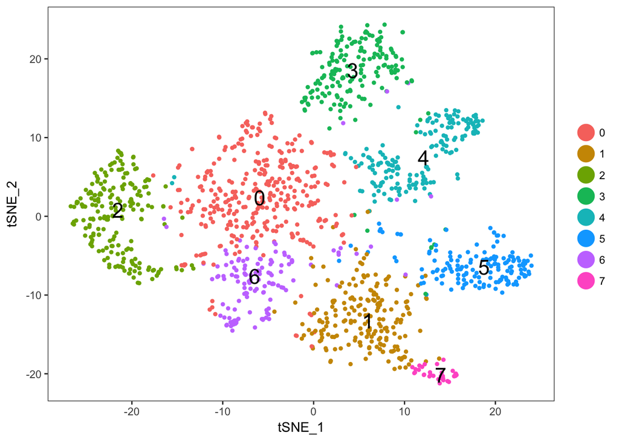

```r
# If cells are too spread out, you can raise the perplexity. If you have few cells, try a lower perplexity (but never less than 10).
tiss <- RunTSNE(object = tiss, dims.use = 1:n.pcs, seed.use = 20, perplexity=45, dim.embed = 2)
# note that you can set do.label=T to help label individual clusters
TSNEPlot(object = tiss, do.label = T, label.size = 6)
```

Check expression of genes of interset.

[figure not shown]

Dotplots let you see the intensity of exppression and the fraction of cells expressing for each of your genes of interest.

[figure not shown]

How big are the clusters?

```r
table(tiss@ident)
```

```
  0   1   2   3   4   5   6   7
329 203 201 178 168 149 131  35
```

```
[1] "Finished averaging RNA for cluster 0"
[1] "Finished averaging RNA for cluster 1"
[1] "Finished averaging RNA for cluster 2"
[1] "Finished averaging RNA for cluster 3"
[1] "Finished averaging RNA for cluster 4"
[1] "Finished averaging RNA for cluster 5"
[1] "Finished averaging RNA for cluster 6"
[1] "Finished averaging RNA for cluster 7"
```

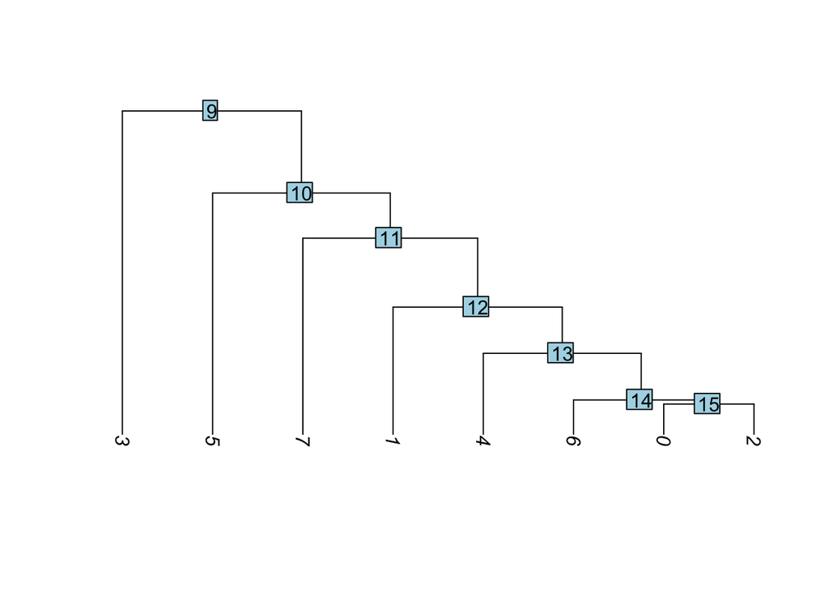

```r
tiss1=BuildClusterTree(tiss)
```

```r
marker15=FindAllMarkersNode(tiss1, 15)
```

```r
print(x = head(x= marker15, n = 30))
```

```
                      p_val   avg_diff pct.1 pct.2 cluster          gene
Tuba1b        3.113025e-122 -1.8051435 0.909 0.995      15        Tuba1b
Tubb5         2.209178e-121 -2.0510135 0.812 0.975      15         Tubb5
Smc4          2.573682e-111 -1.4148837 0.629 1.000      15          Smc4
Ube2c         2.374987e-110 -2.1442986 0.188 0.910      15         Ube2c
Top2a         2.124892e-109 -1.9134055 0.310 0.965      15         Top2a
Stmn1         1.835153e-106 -1.2539741 0.906 1.000      15         Stmn1
Cdk1          1.196138e-105 -1.6137333 0.106 0.920      15          Cdk1
Birc5          3.421245e-98 -1.3111700 0.185 0.950      15         Birc5
Cks1b          3.669976e-97 -1.0169044 0.492 1.000      15         Cks1b
Ccna2          1.482805e-94 -1.5148968 0.131 0.915      15         Ccna2
Kif22          1.410909e-92 -1.2316355 0.046 0.876      15         Kif22
Arl6ip1        2.154387e-91 -1.5405028 0.720 0.970      15       Arl6ip1
Smc2           9.105820e-89 -1.0604782 0.213 0.955      15          Smc2
Prc1           1.790286e-88 -1.1482152 0.283 0.960      15          Prc1
Hist1h4d       5.509923e-88 -0.8627901 0.678 0.856      15      Hist1h4d
Nusap1         3.299491e-87 -0.8479911 0.070 0.861      15        Nusap1
Tacc3          3.471564e-86 -1.3080845 0.264 0.955      15         Tacc3
Aurkb          5.261972e-86 -1.2869065 0.040 0.806      15         Aurkb
Pbk            2.993433e-85 -1.0329130 0.033 0.816      15           Pbk
Ccnb1          3.241462e-85 -1.7680726 0.201 0.930      15         Ccnb1
Hn1            4.079317e-84 -1.3944907 0.766 0.975      15           Hn1
Tubb4b         1.341929e-83 -1.6974743 0.881 0.980      15        Tubb4b
Ube2s          1.087767e-82 -0.6031100 0.924 1.000      15         Ube2s
Cks2           6.053970e-81 -0.7355096 0.742 0.995      15          Cks2
2810417H13Rik  3.249585e-80 -1.0414566 0.106 0.846      15 2810417H13Rik
Cdc20          5.418140e-80 -1.9470410 0.401 0.950      15         Cdc20
Ncaph          1.609506e-78 -0.6857432 0.052 0.816      15         Ncaph
Plk1           7.026965e-78 -1.0909138 0.036 0.761      15          Plk1
Cdca3          6.896282e-76 -1.2096864 0.304 0.925      15         Cdca3
Nek2           1.547359e-75 -0.8396616 0.064 0.821      15          Nek2
```

Which markers identify a specific cluster?

```r
clust.markers <- FindMarkers(object = tiss, ident.1 = 6, only.pos = TRUE, min.pct = 0.25, thresh.use = 0.25)
```

```r
print(x = head(x= clust.markers, n = 30))
```

```
                     p_val  avg_diff pct.1 pct.2
Krt5          4.566485e-46 0.3169047 1.000 0.974
Krt15         1.435598e-43 0.7871068 1.000 0.866
Txnip         9.232247e-35 0.8024241 0.840 0.476
Crip1         2.600089e-34 0.3565734 1.000 0.989
Tsc22d3       4.522253e-34 0.7621824 0.817 0.545
Ptrf          4.803133e-29 0.4995138 1.000 0.984
Ccnd2         2.214327e-26 0.7433042 0.977 0.826
5730469M10Rik 7.408766e-22 0.6421184 0.969 0.698
Cdca7         3.088850e-21 0.5711444 0.840 0.493
Hpgd          9.195239e-21 0.8363320 0.771 0.510
Gas1          4.036891e-20 0.6656261 0.901 0.639
Col17a1       6.457841e-20 0.6047707 0.992 0.822
Vav3          1.143135e-19 0.4698110 0.847 0.732
Lamb3         1.147777e-19 0.6215571 0.985 0.758
Apoe          1.557547e-19 0.4974291 0.985 0.949
Car12         3.065045e-19 0.5609515 0.878 0.630
Ccdc3         3.993906e-19 0.5985825 0.985 0.826
Pappa         9.352265e-19 0.6676825 0.718 0.361
Cav1          2.459876e-18 0.6196316 0.863 0.602
Barx2         3.945061e-18 0.4593194 0.992 0.740
Megf6         7.153566e-18 0.4953077 0.664 0.310
Tmprss11a     1.081919e-17 0.6642276 0.817 0.611
Gpt           3.459121e-17 0.5644408 0.908 0.702
B230120H23Rik 4.567693e-17 0.4741543 0.992 0.964
Ehd2          2.165730e-16 0.5249973 0.916 0.742
Igfbp7        7.657933e-16 0.5148676 0.931 0.766
Anxa5         1.352229e-15 0.2696448 0.992 0.939
Ptk7          1.897756e-15 0.4668404 0.916 0.732
Cdh4          3.916124e-15 0.3578431 0.405 0.139
Dkk3          5.237845e-15 0.4751634 0.908 0.625
```

You can also compute all markers for all clusters at once. This may take some time.

```r
tiss.markers <- FindAllMarkers(object = tiss, only.pos = TRUE, min.pct = 0.25, thresh.use = 0.25)
```

Display the top markers you computed above.

```r
tiss.markers %>% group_by(cluster)
```

| p_val | avg_diff | pct.1 | pct.2 | cluster | gene |
| --- | --- | --- | --- | --- | --- |
| 7.405730e-81 | 0.7928731 | 0.988 | 0.762 | 0 | Tgif1 |
| 1.214396e-78 | 0.6774876 | 0.991 | 0.844 | 0 | Krt15 |
| 2.433051e-76 | 1.1831192 | 0.918 | 0.640 | 0 | Dusp6 |
| 3.129221e-60 | 0.6949640 | 0.979 | 0.804 | 0 | Ifitm3 |
| 3.224378e-60 | 0.9463319 | 0.954 | 0.665 | 0 | Icam1 |
| 4.264571e-51 | 0.4742299 | 0.985 | 0.895 | 0 | Klf9 |
| 1.843814e-46 | 0.7677231 | 0.973 | 0.858 | 0 | Nfkbiz |
| 2.587543e-45 | 0.5115164 | 0.997 | 0.925 | 0 | Mcl1 |
| 6.408914e-45 | 0.6134025 | 0.936 | 0.741 | 0 | 4930523C07Rik |
| 5.740802e-43 | 0.6858911 | 0.897 | 0.555 | 0 | Wfdc2 |

[output cut: 2126 more lines]

```r
write.csv(tiss.markers, "gene_markers_2.csv")
```

## Assigning cell type identity to clusters

At a coarse level, we can use canonical markers to match the unbiased clustering to known cell types:

0: Basal/differentiating cells 1: Basal/differentiating cells 2: Proliferating cells 3: Maturing/nonkeratinizing cells 4: Basal/differentiating cells 5: Stratified/differentiated keratinocytes 6: Basal/differentiating cells 7: Filliform Keratinocytes

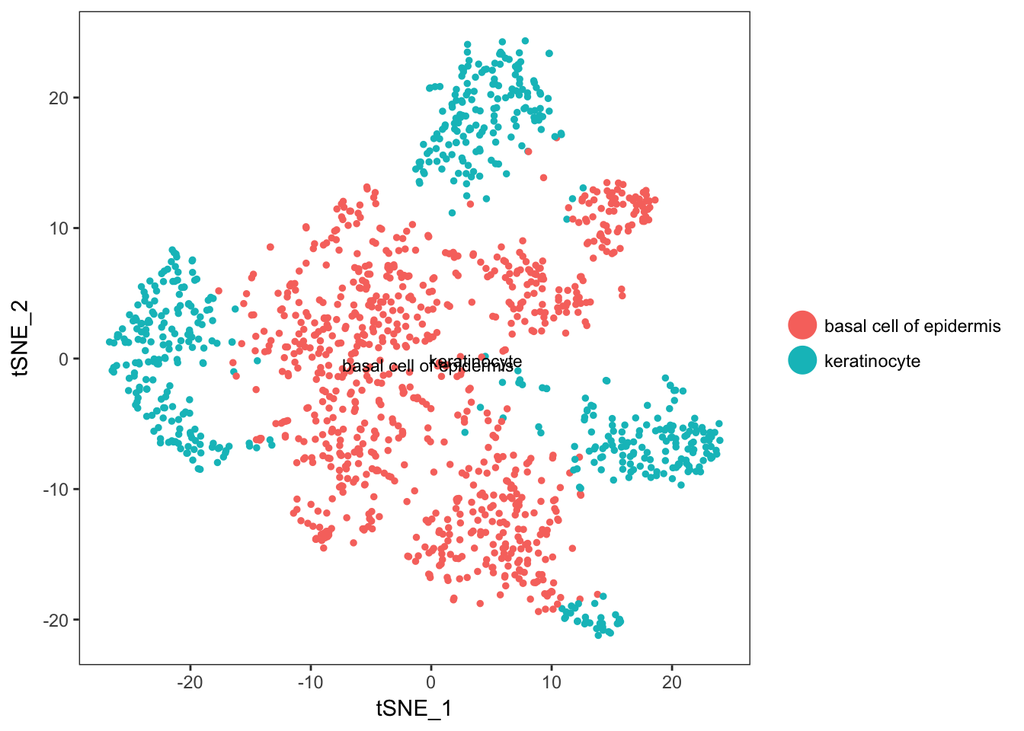

```r
# stash current cluster IDs
tiss <- StashIdent(object = tiss, save.name = "cluster.ids")

# enumerate current cluster IDs and the labels for them
cluster.ids <- c(0, 1, 2, 3, 4, 5, 6, 7)
annotation <- c("basal cell of epidermis", "basal cell of epidermis", "keratinocyte", "keratinocyte", "basal cell of epidermis", "keratinocyte", "basal cell of epidermis", "keratinocyte" )
cell_ontology_id <- c("CL:0000312", "CL:0000312", "CL:0000312", "CL:0000312", "CL:0000312", "CL:0000312", "CL:0000312", "CL:0000312" )

tiss@meta.data[,'annotation'] <- plyr::mapvalues(x = tiss@ident, from = cluster.ids, to = annotation)
tiss@meta.data[,'cell_ontology_id'] <- plyr::mapvalues(x = tiss@ident, from = cluster.ids, to = cell_ontology_id)

tiss@meta.data[tiss@cell.names,'annotation'] <- as.character(tiss@meta.data$annotation)
tiss@meta.data[tiss@cell.names,'cell_ontology_id'] <- as.character(tiss@meta.data$cell_ontology_id)

TSNEPlot(object = tiss, do.label = TRUE, pt.size = 1, label.size = 3, group.by='annotation', do.return = TRUE)
```

```r
#dev.copy(png,'annotated_plot-2.png')
#dev.off()
```

## Checking for batch effects

Color by metadata, like plate barcode, to check for batch effects.

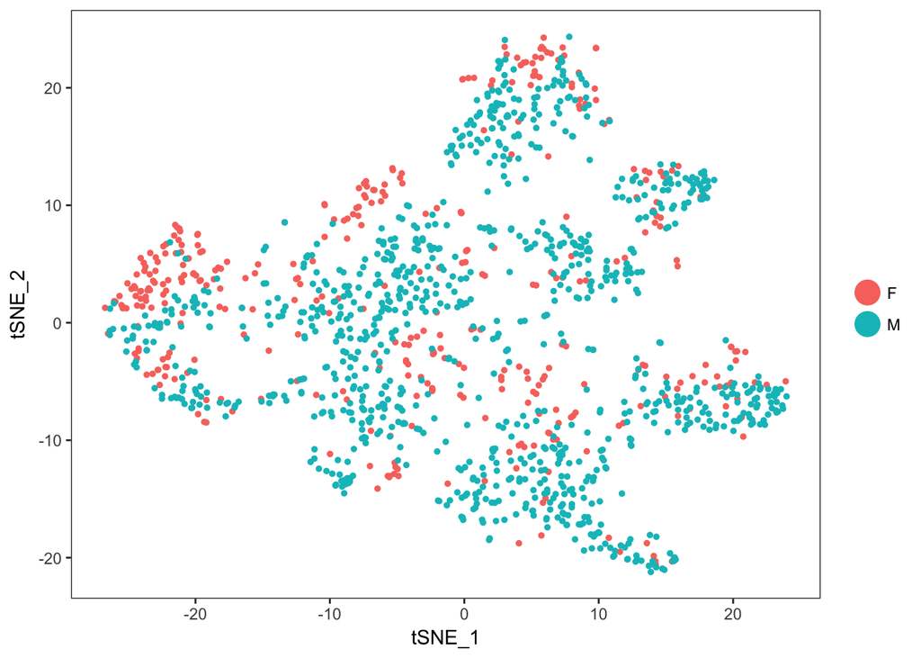

```r
TSNEPlot(object = tiss, do.return = TRUE, group.by = "mouse.sex")
```

Print a table showing the count of cells in each identity category from each plate.

```r
table(as.character(tiss@ident), as.character(tiss@meta.data$plate.barcode))
```

```
    B002777 B002780 D041894 D041904 D041911
  0      42      43      80      74      90
  1      27       7      58      53      58
  2      87      22      30      47      15
  3      39      11      42      45      41
  4      21      10      46      47      44
  5      25      10      38      38      38
  6      21      11      35      15      49
  7       4       3       9      14       5
```

# Save the Robject for later

When you save the annotated tissue, please give it a name.

```r
filename = here('00_data_ingest', 'tissue_seurat_robj',
                     paste0(tissue_of_interest, "_seurat_tiss.Robj"))
print(filename)
```

```
[1] "/Users/olgabot/code/tabula-muris/00_data_ingest/tissue_seurat_robj/Tongue_seurat_tiss.Robj"
```

```r
save(tiss, file=filename)
```

```r
# To reload a saved object
# filename = here('00_data_ingest', 'tissue_seurat_robj',
#                      paste0(tissue_of_interest, "_seurat_tiss.Robj"))
# load(file=filename)
```

# Export the final metadata

So that Biohub can easily combine all your annotations, please export them as a simple csv.

```r
head(tiss@meta.data)
```

| nGene | nReads | orig.ident | plate.barcode | mouse.id | tissue | subtissue | FACS.selection | mouse.sex | percent.ercc | annotation | subannotation | percent.ribo | res.0.9 | cluster.ids | cell_ontology_id |
| --- | --- | --- | --- | --- | --- | --- | --- | --- | --- | --- | --- | --- | --- | --- | --- |
| 2895 | 1047320 | Tongue | B002777 | 3_39_F | Tongue | NA | Multiple | F | 0.022699660 | basal cell of epidermis | NA | 0.06341626 | 1 | 1 | CL:0000312 |
| 4336 | 1698448 | Tongue | B002777 | 3_39_F | Tongue | NA | Multiple | F | 0.009259637 | basal cell of epidermis | NA | 0.05555713 | 1 | 1 | CL:0000312 |
| 5787 | 1029604 | Tongue | B002777 | 3_39_F | Tongue | NA | Multiple | F | 0.005658338 | keratinocyte | NA | 0.04716635 | 2 | 2 | CL:0000312 |
| 3687 | 603449 | Tongue | B002777 | 3_39_F | Tongue | NA | Multiple | F | 0.011159196 | basal cell of epidermis | NA | 0.06775268 | 0 | 0 | CL:0000312 |
| 4615 | 822144 | Tongue | B002777 | 3_39_F | Tongue | NA | Multiple | F | 0.007986602 | keratinocyte | NA | 0.04162420 | 2 | 2 | CL:0000312 |
| 3342 | 793139 | Tongue | B002777 | 3_39_F | Tongue | NA | Multiple | F | 0.018776073 | basal cell of epidermis | NA | 0.07732576 | 1 | 1 | CL:0000312 |

```r
filename = here('00_data_ingest', 'tissue_annotation_csv',
                     paste0(tissue_of_interest, "_annotation.csv"))
write.csv(tiss@meta.data[,c('plate.barcode','annotation','cell_ontology_id')], file=filename)
```